# P5-Identify-Fraud-from-Enron-Email

### Udacity / Data Analyst Nanodegree 10'2016

### P5: Identify Fraud from Enron Email

## 1. Introduction & Objective of the Analysis

In 2002, Enron, one of the largest companies in the United States, had collapsed into bankruptcy due to widespread corporate fraud. The dataset was originally made public by the Federal Energy Regulatory Commission during its investigation.

The goal was to perform data analysis on Enron dataset to identify Enron employees, who may have committed fraud. I put my machine learning skills to build, tune, evaluate the best performing algorithm, by trying various combinations of supervised classification algorithms and parameters, engineer the features, draw conclusion to make sense of the analysis process and communicatie it to others.

## 2. Dataset Overview

### 2.1 Exploring the Outliers

The dataset contains data of 146 records, with financial and email information organized into 21 features for each. It is not a large dataset to get very clear analysis for a machine learning. The 'poi' feature records whether the person is a person of interest. The dataset contains 18 known 'poi'. To proceed with the analysis, the first feature is separated and put into its own label/target list, and the rest in features list.

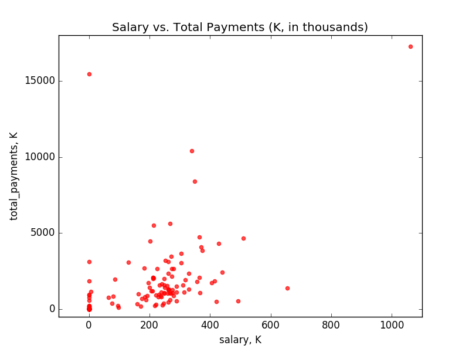

```python
from IPython.display import Image
Image("figure_1.png")
```

The exploration of the combined email and finance dataset revealed that **TOTAL** and **THE TRAVEL AGENCY IN THE PARK** are not a person. Also, the values of all features for **CHAN RONNIE** is 0. These data points are removed in the procccess of feature formating, by a helper function, featureFormat().

The final dataset contains 143 persons.

### 2.2 Exploring the Features

I calculated new features: **fraction_from_poi** and **fraction_to_poi**. The features **from_poi_to_this_person**, **from_this_person_to_poi**, **to_messages**, **from_messages** are removed, since these were used to calculate the new ones. I performed testing these new features using my final choice - Decision Tree Classifier. See Evaluation 7 and Evaluation 8 for the metrics performing the testing with features included and excluded respectively.

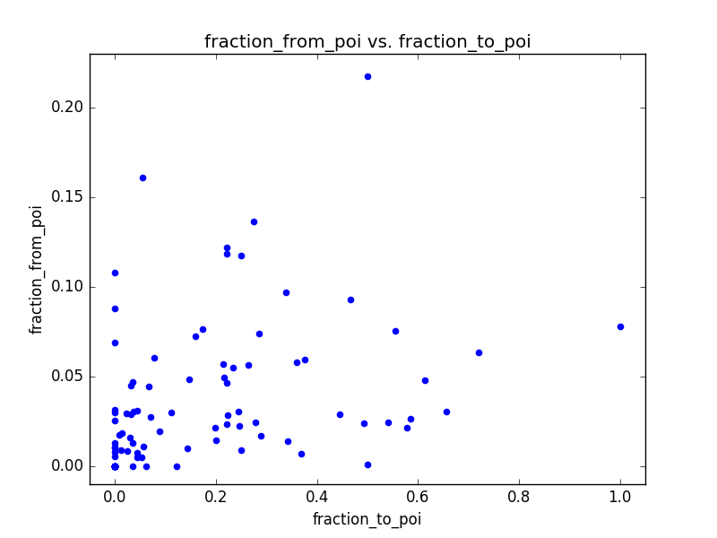

```python
Image("figure_2.png")
```

Testing new features: the plot in Figure 2 gives me intuition that there are more than few people very active in corresponding with known POI.

I made some calculations to see if I can remove **salary**, **deferral_payments**, **bonus**, **expenses**, **loan_advances**, **other**, **deferred_income**, **long_term_incentive** features, since **total_payments** are a sum of these features. But not for all data points this equation is valid. Did not remove the above mentioned features.

I made some calculations to see if the features **exercised_stock_options**, **restricted_stock** could be removed, since the **total_stock_value** is a sum of these. Again, not for all data points this equation is valid. So, I did not remove these features.

For a final step I have selected two algorithms **GaussianNB Classifier** and **Decison Tree Classifier** to test and narrow my choices. Both are using automated feature selection.

  ```
    explained_variance_ratio:
    [ 0.32998616  0.1344917   0.10834923  0.09720135  0.06934314  0.06234034 0.04079523  0.0361167 ]
  ```

In the table below the values reveal which variables are most strongly correlated with each component. For the first component the correlation values are of moderate importance for **salary** and **shared_receipt_with_poi** features. The second and third principal components are strongly correlated with **director_fees** feature.

```
                             PC1       PC2       PC3       PC4       PC5        PC6       PC7       PC8
salary                     0.431285  0.038961 -0.041651  0.015076 -0.013334   0.162536 -0.122661  0.228397
deferral_payments          0.081906 -0.010998  0.049766 -0.148566 -0.133163   0.339690  0.092638 -0.043584
total_payments             0.165907  0.172076  0.054000 -0.020190  0.044205  -0.151506 -0.022535  0.158164
loan_advances              0.133377  0.180126  0.067228 -0.014196  0.026935  -0.194567 -0.013124  0.120819
bonus                      0.324004  0.059897 -0.127338  0.000537  0.243320  -0.083828 -0.096991  0.102850
restricted_stock_deferred -0.014807 -0.003427 -0.017957 -0.022021  0.033720  -0.177485  0.054817  0.211769
deferred_income           -0.164647 -0.059738 -0.076915  0.230563  0.351225  -0.669154 -0.106025  0.116692
total_stock_value          0.246834  0.295746  0.193499  0.018002 -0.058712  -0.133957 -0.003756 -0.323616
expenses                   0.233960 -0.082818 -0.473895  0.486240 -0.648165  -0.149426  0.052668  0.074080
exercised_stock_options    0.249089  0.309375  0.218455 -0.001677 -0.087446  -0.092775 -0.023748 -0.412169
other                      0.201193  0.212154  0.097023 -0.054807 -0.039913  -0.010092  0.010278  0.216270
long_term_incentive        0.229327  0.124846  0.060022 -0.057648  0.124667   0.187826 -0.133688  0.596494
restricted_stock           0.243382  0.264446  0.137603  0.066460  0.004066  -0.208292  0.036124 -0.143209
director_fees             -0.245979  0.573167 -0.635193 -0.436927 -0.035803  -0.030278 -0.047607 -0.019724
shared_receipt_with_poi    0.411090 -0.252863 -0.467867  0.037360  0.520101   0.157805  0.138454 -0.324879
fraction_from_poi          0.149736 -0.350553 -0.029710 -0.401085 -0.201437  -0.173909 -0.761128 -0.137984
fraction_to_poi            0.218468 -0.305328  0.030900 -0.568134 -0.187034  -0.356899  0.573282  0.095503
```

- Using **SelectKBest()** to select features according to the k highest scores. SelectKBest runs statistical tests on each variable and calculates scores and p-values for each. I chose k = 10, features with highest scores and p-value less than 1%.

```
('salary', '18.25', '0.000')
('bonus', '19.82', '0.000')
('total_stock_value', '15.11', '0.000')
('exercised_stock_options', '14.13', '0.000')
('fraction_to_poi', '16.93', '0.000')
('restricted_stock', '10.03', '0.002')
('total_payments', '9.18', '0.003')
('long_term_incentive', '7.89', '0.006')
('shared_receipt_with_poi', '7.85', '0.006')
('loan_advances', '7.24', '0.008')
```

Following is the result of the features which made to the best 10 list per each cross validation fold. The new feature **fraction_to_poi** is clearly very significant. It appeard 5 times in top 10, with fold = 6.

```
{'salary': 6, 'total_payments': 2, 'bonus': 6, 'total_stock_value': 6, 'shared_receipt_with_poi': 2,  'exercised_stock_options': 6,'fraction_to_poi': 5, 'deferred_income': 4, 'restricted_stock': 3, 'long_term_incentive': 2}
```

- Using **FeatureUnion()** to build estimator from **PCA** and **SelectKBest** selection. This estimator applies a list of transformer objects in parallel to the input data, then concatenates the results. This is useful to combine several feature extraction mechanisms into a single transformer.

## 3. Algorithm selection

Algorithm selection is very important step in the analysis. Since I don't have a lot of data and data are labeled, I should use a supervised learning classifier with high bias. My goal is to create a model that predicts the value of a target variable by learning decision rules inferred from the training data, where each data point is a pair consisting of an input object (typically a vector) and a desired output value.

These are the algorithms I tried to create my model.

- **DecisionTreeClassifier** - supervised learning method used for classification and regression. See the metrics Evaluation 1
- **GaussianNB** - implements the Gaussian Naive Bayes algorithm for classification. See Evaluation 2
- **AdaBoostClassifier** - the principle of AdaBoost is to fit a sequence of weak learners (i.e., models that are only slightly better than random guessing, such as small decision trees) on repeatedly modified versions of the data. AdaBoost can be used both for classification and regression problems. See Evaluation 3
- **RandomForestClassifier** - includes two averaging algorithms based on randomized decision trees: the RandomForest algorithm and the Extra-Trees method. See Evaluation 4
- Support vector machines **SVM** - a set of supervised learning methods used for classification, regression and outliers detection. See Evaluation 5

These algorithms I picked for the final run, using parameter tuning and validation functions:

- **GaussianNB** Classifier ( new features included in the dataset ). See Evaluation 6.
- **DecisionTreeClassifier** ( new features included in the dataset ). See Evaluation 7.
- **DecisionTreeClassifier** ( new features excluded from the dataset ).See Evaluation 8.

## 4. Evaluation

### 4.1 Parameter Tuning

Parameter tuning is a process of trying and testing various parameters which are passed as arguments to the constructor of the estimator classes. It is important because it helps to find better algorithm. To start using an algorithm, we need beforehand to set parameter values, and later try various combinations of these to see which set of the parameters perform the best when training, in order to improve the fit on the test set.

In my project I was using **GridSearchCV** in **SVC** and **Decision Tree** models to perform search over supplied parameter values (kernel, C, gamma values), and all the possible combinations of values are evaluated and the best combination is returned.

**GridSearchCV** - Exhaustive search over specified parameter values for an estimator. The parameters of the estimator are used to apply to fit and predict functions, and are optimized by grid-search over a parameter grid.

To compute the metrics using **Support Vector Classification**:

- The parameters passed: parameters = {"kernel":['rbf'], "C":[1, 1000],"gamma": [0.0001, 0.0005, 0.001, 0.005, 0.01, 0.1]}
- The best SVC parameters: {'kernel': 'rbf', 'C': 1, 'gamma': 0.0001}

To compute the metrics using Decision Tree Classifier:

- The parameters passed: parameters = {"criterion" : ["gini", "entropy"],"min_samples_split": [2,3] }
- Decision Tree best parameters : {'min_samples_split': 2, 'criterion': 'entropy'}

### 4.3 Picking Metrics

- The **accuracy_score** function computes the accuracy, either the fraction or the count of correct predictions from all predictions made.
- The **recall** is the ratio **tp / (tp + fn)** where **tp** is the number of true positives and **fn** the number of false negatives. The **recall** is intuitively the ability of the classifier to find all the positive samples. In this project, recall is the ratio of POI's recognised by the model and all POI's that existed in the dataset. The best value is 1.
- The **precision** is the ratio **tp / (tp + fp)** where **tp** is the number of true positives and **fp** the number of false positives. The **precision** is intuitively the ability of the classifier not to label as positive a sample that is negative. That is, in my project, the precision shows the ratio of recognised POI's and of all the people picked out by a model as POI. The best value is 1.
- The **F1** score can be interpreted as a weighted average of the **precision** and **recall**. Best value is 1. The relative contribution of **precision** and **recall** to the **F1** score are equal. The formula is: **F1 = 2 *(precision* recall) / (precision + recall)**.

### 4.4 Evaluation metrics ( new features included in the dataset )

**Evaluation 1:** Decision Tree Classifier

DecisionTreeClassifier( class_weight = None, criterion = "entropy", max_depth = None, max_features = "auto", max_leaf_nodes = None, min_samples_leaf = 1, min_samples_split = 3, min_weight_fraction_leaf = 0.0, presort = False, random_staten = 42, splitter = "best" )

| Classifier score | Metrics |
| --- | --- |
| Decision Tree accuracy: | 0.882 |
| Decision Tree recall_score: | 0.2 |
| Decision Tree precision_score: | 0.333 |
| Decision Tree f1_score: | 0.25 |

**Evaluation 2**: Gaussian Naive Bayes

GaussianNB()

| Classifier score | Metrics |
| --- | --- |
| GaussianNB accuracy: | 0.902 |
| GaussianNB recall_score: | 0.4 |
| GaussianNB precision_score: | 0.5 |
| GaussianNB f1_score: | 0.444 |

**Evaluation 3**: AdaBoost classifier

AdaBoostClassifier( algorithm="SAMME.R", n_estimators=300, random_state=0 )

| Classifier score | Metrics |
| --- | --- |
| AdaBoostClassifier accuracy: | 0.824 |
| AdaBoostClassifier recall_score: | 0.2 |
| AdaBoostClassifier precision_score: | 0.167 |
| AdaBoostClassifier f1_score: | 0.182 |

**Evaluation 4**: Forests of randomized trees

RandomForestClassifier( n_estimators=500, min_samples_split=2, max_depth=20, min_samples_leaf=2 )

| Classifier score | Metrics |
| --- | --- |
| RandomForestClassifier accuracy: | 0.922 |
| RandomForestClassifier recall_score: | 0.2 |
| RandomForestClassifier precision_score: | 1.0 |
| RandomForestClassifier f1_score: | 0.333 |

**Evaluation 5**: Support vector machines (SVM)

SVC( kernel="rbf", C=1000 )

| Classifier score | Metrics |
| --- | --- |
| SVC accuracy: | 0.902 |
| SVC recall_score: | 0.0 |
| SVC precision_score: | 0.0 |
| SVC f1_score: | 0.0 |

### 4.5 Final Algorithm Evaluation Metrics ( with new features included in the dataset )

**Evaluation 6**:

Computed metrics using GaussianNB Classifier:

| Metrics / parameters | **1** | **2** | **3** | **4** | **5** | **6** |
| --- | --- | --- | --- | --- | --- | --- |
| Kfold folds | 4 | 4 | 4 | 5 | 5 | 5 |
| PCA n_components | 10 | 7 | 5 | 10 | 7 | 5 |
| SelectKBest k | 10 | 7 | 5 | 10 | 7 | 5 |
| GaussianNB average accuracy | 0.658 | 0.721 | **0.748** | 0.607 | 0.587 | 0.72 |
| GaussianNB average recall_score | 0.771 | 0.721 | **0.679** | 0.813 | 0.733 | 0.667 |
| GaussianNB average precision_score | 0.245 | 0.271 | **0.299** | 0.229 | 0.206 | 0.263 |
| GaussianNB average f1_score | 0.368 | 0.388 | **0.408** | 0.339 | 0.298 | 0.356 |

**Evaluation 7**:

Computed metrics using Decision Tree Classifier. The last column **12** holds metrics received with LAY KENNETH L data point removed:

| Metrics / parameters | **1** | **2** | **3** | **4** | **5** | **6** | **7** | **9** | **10** | **11** | **12** |
| --- | --- | --- | --- | --- | --- | --- | --- | --- | --- | --- | --- |
| Kfold folds | 4 | 4 | 4 | 5 | 5 | 5 | 6 | 6 | 6 | 6 | 6 |
| PCA n_components | 10 | 7 | 5 | 10 | 7 | 5 | 10 | 10 | 7 | 5 | 7 |
| SelectKBest k | 10 | 7 | 5 | 10 | 7 | 5 | 10 | 9 | 7 | 5 | 7 |
| Decision Tree average accuracy: | 0.804 | 0.832 | 0.798 | 0.853 | 0.798 | 0.798 | 0.805 | 0.861 | 0.846 | 0.811 | 0.852 |
| Decision Tree average recall_score: | 0.292 | 0.237 | 0.163 | 0.327 | 0.18 | 0.18 | 0.347 | 0.403 | 0.514 | 0.208 | 0.444 |
| Decision Tree average precision_score: | 0.243 | 0.333 | 0.229 | 0.337 | 0.1 | 0.1 | 0.353 | 0.567 | 0.4 | 0.236 | 0.383 |
| Decision Tree average f1_score: | 0.248 | 0.26 | 0.188 | 0.317 | 0.128 | 0.128 | 0.323 | 0.437 | 0.428 | 0.207 | 0.401 |

### 4.6 Final Algorithm Evaluation Metrics ( with new features excluded from the dataset )

**Evaluation 8**:

Computed metrics using Decision Tree Classifier:

| Metrics / parameters | **1** | **2** | **3** | **4** | **5** | **6** | **7** | **9** | **10** | **11** |
| --- | --- | --- | --- | --- | --- | --- | --- | --- | --- | --- |
| Kfold folds | 4 | 4 | 4 | 5 | 5 | 5 | 6 | 6 | 6 | 6 |
| PCA n_components | 10 | 7 | 5 | 10 | 7 | 5 | 10 | 10 | 7 | 5 |
| SelectKBest k | 10 | 7 | 5 | 10 | 7 | 5 | 10 | 9 | 7 | 5 |
| Decision Tree average accuracy: | 0.819 | 0.777 | 0.79 | 0.812 | 0.812 | 0.791 | 0.804 | 0.789 | 0.84 | 0.769 |
| Decision Tree average recall_score: | 0.275 | 0.454 | 0.371 | 0.287 | 0.44 | 0.44 | 0.25 | 0.0 | 0.347 | 0.236 |
| Decision Tree average precision_score: | 0.271 | 0.299 | 0.261 | 0.287 | 0.267 | 0.502 | 0.347 | 0.0 | 0.431 | 0.2 |
| Decision Tree average f1_score: | 0.267 | 0.334 | 0.292 | 0.28 | 0.301 | 0.319 | 0.261 | 0.0 | 0.355 | 0.198 |

## 5. CONCLUSION

The best computed metrics were received using Decision Tree Classifier with new features included in the dataset. See column 9 in Evaluation 7:

Kfold folds = 6

PCA n_components = 10

SelectKBest k = 9

DT average accuracy: 0.861

DT average recall_score: 0.403

DT average precision_score: 0.567

DT average f1_score: 0.437

```python
%%html
<style>
table {float:left;
      color: #000080}
</style>
```

## 6. RESOURCES

http://stats.stackexchange.com/questions/2691/making-sense-of-principal-component-analysis-eigenvectors-eigenvalues